# DSDA 1995

Data Science and Society using R

Lecture 14 | Geospatial Data I

## Plan for Today

- Exploring geolocated data in R
- Examining the `sp` and `sf` packages
- Discuss geographic data

## What is Geographic Data?

- Geographic data corresponds to data that have been linked to a geographic coordinate system
  - Think latitude and longitude
- Working with geographically located data is a relatively new phenomenon
  - It requires a significant amount of computing power and specialized programs
- Nowadays such lack of geographic data is hard to imagine
  - Every smartphone has a global positioning (GPS) receiver and a multitude of sensors on devices ranging from satellites and semi-autonomous vehicles to citizen scientists incessantly measure every part of the world

## What is Geographic Data?

```r
#install.packages("leaflet")
library(leaflet)

popup = c("Storrs, Connecticut")
leaflet() %>%
  setView(lng = -72.251194, lat = 41.807417, zoom = 1)%>%
  addProviderTiles("NASAGIBS.ViirsEarthAtNight2012") %>%
    addMarkers(lng = c(-72.251194),
             lat = c(41.807417),
             popup = popup)
```

[interactive chart not shown]

## What is Geographic Data?

```r
popup = c("SSH Building")
leaflet() %>%
  setView(lng = -72.251194, lat = 41.807417, zoom = 12)%>%
  addTiles() %>%
  addMarkers(lng = c(-72.251194),
             lat = c(41.807417),
             popup = popup)
```

[interactive chart not shown]

## How Does R Handle Geography?

- There are many ways to handle geographic data in R, with dozens of packages in the area
- The ones that we will focus on in this course are:
  - `sp`
  - `sf` (very functional with the `tidyverse`)
  - `raster`
- Honorable mentions
  - `maptools`
  - `rgdal`

## The `sp` Package

- The first general package to provide classes and methods for spatial data types that was developed for R is called `sp`
- The package provides classes and methods to create points, lines, polygons, and grids and to operate on them
- Let’s build a `sp` object:

```r
#install.packages("sp")
library(sp)

#create the highways
ln1 <- Line(matrix(runif(6), ncol=2))
ln1
```

```
An object of class "Line"
Slot "coords":
          [,1]      [,2]
[1,] 0.6786050 0.4377631
[2,] 0.8160567 0.9537950
[3,] 0.5257958 0.5667340
```

```r
ln2 <- Line(matrix(runif(6), ncol=2))
ln2
```

```
An object of class "Line"
Slot "coords":
          [,1]      [,2]
[1,] 0.5710207 0.1718490
[2,] 0.5149765 0.4698802
[3,] 0.1490663 0.7644061
```

```r
str(ln1)
```

```
Formal class 'Line' [package "sp"] with 1 slot
  ..@ coords: num [1:3, 1:2] 0.679 0.816 0.526 0.438 0.954 ...
```

- Note that the `@coords` slot holds the coordinates

## The `sp` Package

```r
#combine the highways to a Lines object
lns1 <- Lines(list(ln1), ID = c("hwy1"))
lns2 <- Lines(list(ln2), ID = c("hwy2"))

str(lns1)
```

```
Formal class 'Lines' [package "sp"] with 2 slots
  ..@ Lines:List of 1
  .. ..$ :Formal class 'Line' [package "sp"] with 1 slot
  .. .. .. ..@ coords: num [1:3, 1:2] 0.679 0.816 0.526 0.438 0.954 ...
  ..@ ID   : chr "hwy1"
```

- The `Line` objects are now in a list and we have an additional ID slot, which uniquely identifies each `Line` object

```r
#create a geospatial object with SpatialLines
sp_lns <- SpatialLines(list(lns1, lns2))

str(sp_lns)
```

```
Formal class 'SpatialLines' [package "sp"] with 3 slots
  ..@ lines      :List of 2
  .. ..$ :Formal class 'Lines' [package "sp"] with 2 slots
  .. .. .. ..@ Lines:List of 1
  .. .. .. .. ..$ :Formal class 'Line' [package "sp"] with 1 slot
  .. .. .. .. .. .. ..@ coords: num [1:3, 1:2] 0.679 0.816 0.526 0.438 0.954 ...
  .. .. .. ..@ ID   : chr "hwy1"
  .. ..$ :Formal class 'Lines' [package "sp"] with 2 slots
  .. .. .. ..@ Lines:List of 1
  .. .. .. .. ..$ :Formal class 'Line' [package "sp"] with 1 slot
  .. .. .. .. .. .. ..@ coords: num [1:3, 1:2] 0.571 0.515 0.149 0.172 0.47 ...
  .. .. .. ..@ ID   : chr "hwy2"
  ..@ bbox       : num [1:2, 1:2] 0.149 0.172 0.816 0.954
  .. ..- attr(*, "dimnames")=List of 2
  .. .. ..$ : chr [1:2] "x" "y"
  .. .. ..$ : chr [1:2] "min" "max"
  ..@ proj4string:Formal class 'CRS' [package "sp"] with 1 slot
  .. .. ..@ projargs: chr NA
```

## The `sp` Package

```r
#create a SpatialLinesDataframe
dfr <- data.frame(id = c("hwy1", "hwy2"), # note how we use the same IDs from above!
                  cars_per_hour = c(78, 22))

sp_lns_dfr <- SpatialLinesDataFrame(sp_lns, dfr, match.ID = "id")

str(sp_lns_dfr)
```

```
Formal class 'SpatialLinesDataFrame' [package "sp"] with 4 slots
  ..@ data       :'data.frame': 2 obs. of  2 variables:
  .. ..$ id           : chr [1:2] "hwy1" "hwy2"
  .. ..$ cars_per_hour: num [1:2] 78 22
  ..@ lines      :List of 2
  .. ..$ :Formal class 'Lines' [package "sp"] with 2 slots
  .. .. .. ..@ Lines:List of 1
  .. .. .. .. ..$ :Formal class 'Line' [package "sp"] with 1 slot
  .. .. .. .. .. .. ..@ coords: num [1:3, 1:2] 0.679 0.816 0.526 0.438 0.954 ...
  .. .. .. ..@ ID   : chr "hwy1"
  .. ..$ :Formal class 'Lines' [package "sp"] with 2 slots
  .. .. .. ..@ Lines:List of 1
  .. .. .. .. ..$ :Formal class 'Line' [package "sp"] with 1 slot
  .. .. .. .. .. .. ..@ coords: num [1:3, 1:2] 0.571 0.515 0.149 0.172 0.47 ...
  .. .. .. ..@ ID   : chr "hwy2"
  ..@ bbox       : num [1:2, 1:2] 0.149 0.172 0.816 0.954
  .. ..- attr(*, "dimnames")=List of 2
  .. .. ..$ : chr [1:2] "x" "y"
  .. .. ..$ : chr [1:2] "min" "max"
  ..@ proj4string:Formal class 'CRS' [package "sp"] with 1 slot
  .. .. ..@ projargs: chr NA
```

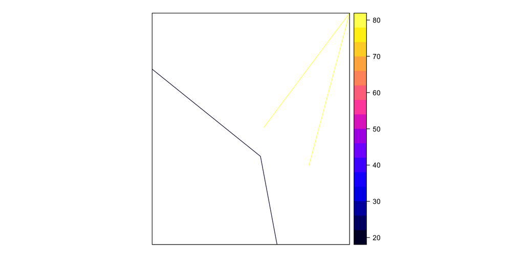

```r
spplot(sp_lns_dfr, "cars_per_hour")
```

- Useful things to know in `sp`

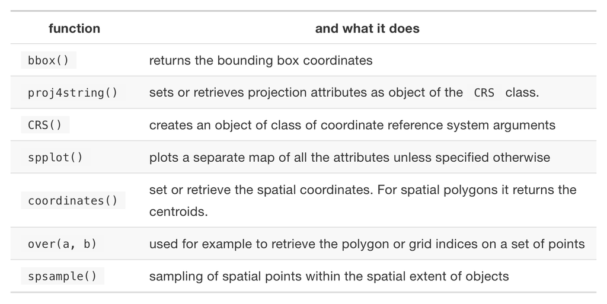

## The `sf` Package

- `sf` implements a formal standard called “Simple Features” that specifies a storage and access model of spatial geometries (point, line, polygon)
- A feature geometry is called simple when it consists of points connected by straight line pieces, and does not intersect itself
  - This standard has been adopted widely
- Data are structured and conceptualized very differently from the `sp` approach

## `sf` Package

- Let’s recreate the `sp` object from above in `sf`

```r
#install.packages("sf")
library(sf)

#create the highways
lnstr_sfg1 <- st_linestring(matrix(runif(6), ncol=2))
lnstr_sfg1

lnstr_sfg2 <- st_linestring(matrix(runif(6), ncol=2))
lnstr_sfg2

class(lnstr_sfg1)
```

```
[1] "XY"         "LINESTRING" "sfg"
```

- We would then combine this into a simple feature collection

```r
#combine the highways into a simple feature
lnstr_sfc <- st_sfc(lnstr_sfg1, lnstr_sfg2) # just one feature here
lnstr_sfc
```

```
Geometry set for 2 features
Geometry type: LINESTRING
Dimension:     XY
Bounding box:  xmin: 0.07499539 ymin: 0.2966532 xmax: 0.8309161 ymax: 0.9442507
CRS:           NA
```

```r
#create our spatial data frame
lnstr_sf <- st_sf(dfr , lnstr_sfc)
lnstr_sf
```

```
Simple feature collection with 2 features and 2 fields
Geometry type: LINESTRING
Dimension:     XY
Bounding box:  xmin: 0.07499539 ymin: 0.2966532 xmax: 0.8309161 ymax: 0.9442507
CRS:           NA
    id cars_per_hour                      lnstr_sfc
1 hwy1            78 LINESTRING (0.6654251 0.336...
2 hwy2            22 LINESTRING (0.8309161 0.421...
```

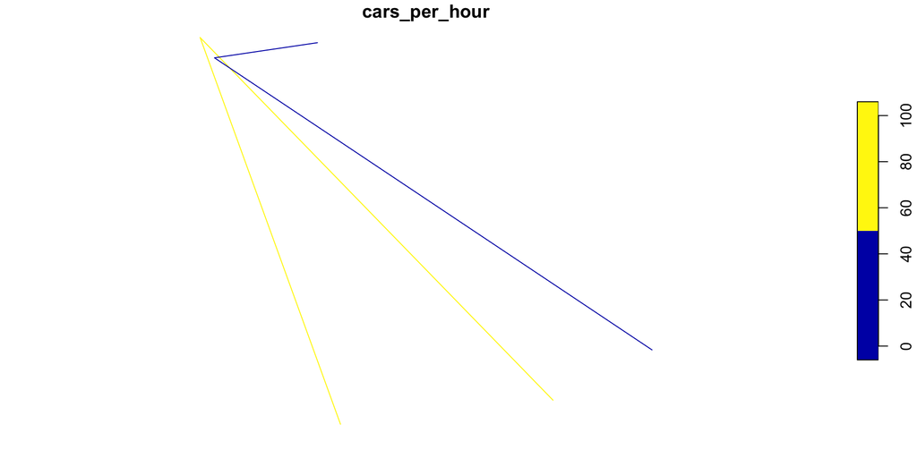

```r
plot(lnstr_sf["cars_per_hour"])
```

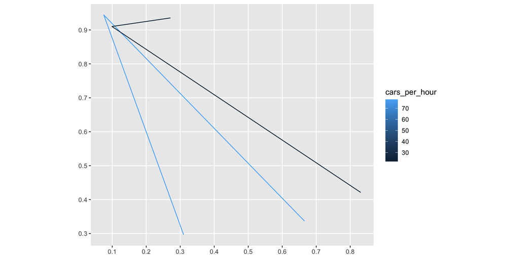

```r
ggplot(lnstr_sf) +
  geom_sf(aes(color = cars_per_hour))
```

- Useful methods in `sf`

```r
methods(class = "sf")
```

```
  [1] [                            [[<-
  [3] [<-                          $<-
  [5] aggregate                    anti_join
  [7] arrange                      as.data.frame
  [9] cbind                        coerce
 [11] dbDataType                   dbWriteTable
 [13] distinct                     dplyr_reconstruct
 [15] drop_na                      duplicated
 [17] filter                       full_join
 [19] gather                       group_by
 [21] group_split                  identify
 [23] initialize                   inner_join
 [25] left_join                    merge
 [27] mutate                       nest
 [29] pivot_longer                 pivot_wider
```

[output cut: 44 more lines]

## Raster Data

- Raster files, as you might know, have a much more compact data structure than vectors
- A raster is defined by:
  - a CRS
  - coordinates of its origin
  - a distance or cell size in each direction
  - a dimension or numbers of cells in each direction
  - an array of cell values

## Raster Data

```r
#install.packages("raster")
library(raster)

HARV <- raster("HARV_RGB_Ortho.tif")

HARV
```

```
class      : RasterLayer
band       : 1  (of  3  bands)
dimensions : 2317, 3073, 7120141  (nrow, ncol, ncell)
resolution : 0.25, 0.25  (x, y)
extent     : 731998.5, 732766.8, 4712956, 4713536  (xmin, xmax, ymin, ymax)
crs        : +proj=utm +zone=18 +datum=WGS84 +units=m +no_defs
source     : HARV_RGB_Ortho.tif
names      : HARV_RGB_Ortho_1
values     : 0, 255  (min, max)
```

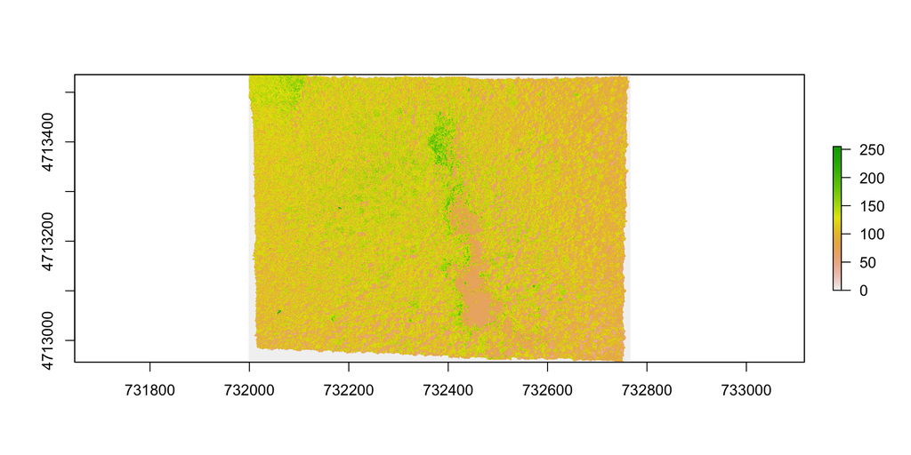

```r
plot(HARV)
```

- This raster is generated as part of the NEON Harvard Forest field [site](https://www.neonscience.org/field-sites/harv)

```r
#useful commands

crs(HARV)
```

```
Coordinate Reference System:
Deprecated Proj.4 representation:
 +proj=utm +zone=18 +datum=WGS84 +units=m +no_defs
WKT2 2019 representation:
PROJCRS["unknown",
    BASEGEOGCRS["unknown",
        DATUM["World Geodetic System 1984",
            ELLIPSOID["WGS 84",6378137,298.257223563,
                LENGTHUNIT["metre",1]],
            ID["EPSG",6326]],
        PRIMEM["Greenwich",0,
            ANGLEUNIT["degree",0.0174532925199433],
            ID["EPSG",8901]]],
    CONVERSION["UTM zone 18N",
        METHOD["Transverse Mercator",
            ID["EPSG",9807]],
        PARAMETER["Latitude of natural origin",0,
            ANGLEUNIT["degree",0.0174532925199433],
            ID["EPSG",8801]],
        PARAMETER["Longitude of natural origin",-75,
            ANGLEUNIT["degree",0.0174532925199433],
            ID["EPSG",8802]],
        PARAMETER["Scale factor at natural origin",0.9996,
            SCALEUNIT["unity",1],
            ID["EPSG",8805]],
        PARAMETER["False easting",500000,
            LENGTHUNIT["metre",1],
            ID["EPSG",8806]],
        PARAMETER["False northing",0,
            LENGTHUNIT["metre",1],
            ID["EPSG",8807]],
        ID["EPSG",16018]],
    CS[Cartesian,2],
        AXIS["(E)",east,
            ORDER[1],
            LENGTHUNIT["metre",1,
                ID["EPSG",9001]]],
        AXIS["(N)",north,
            ORDER[2],
            LENGTHUNIT["metre",1,
                ID["EPSG",9001]]]]
```

```r
methods(class = class(HARV))
```

```
  [1] !                     !=                    [
  [4] [[                    [[<-                  [<-
  [7] %in%                  ==                    $
 [10] $<-                   addLayer              adjacent
 [13] aggregate             all.equal             area
 [16] Arith                 as.array              as.character
 [19] as.data.frame         as.factor             as.integer
 [22] as.list               as.logical            as.matrix
 [25] as.raster             as.vector             asFactor
 [28] atan2                 bandnr                barplot
 [31] bbox                  blockSize             boundaries
 [34] boxplot               brick                 buffer
 [37] calc                  cellFromRowCol        cellFromRowColCombine
 [40] cellFromXY            cellStats             clamp
 [43] click                 clump                 coerce
```

[output cut: 52 more lines]